# Chapter 3 Dimensionality reduction

## 3.4 Pairwise comparison of gene and metadata distribution

As a final step to aid in feature selection, ClustAssess allows for UMAP visualization of gene expression across multiple genes and metadata features. You can select one or multiple genes and compare their expression at the single cell level to other genes of interest. When selecting more than one gene, you can set a gene expression threshold to highlight cells that express the given set of genes above the threshold. Two additional UMAP plots are provided to enable evaluation of gene expression in relation to any available metadata features.

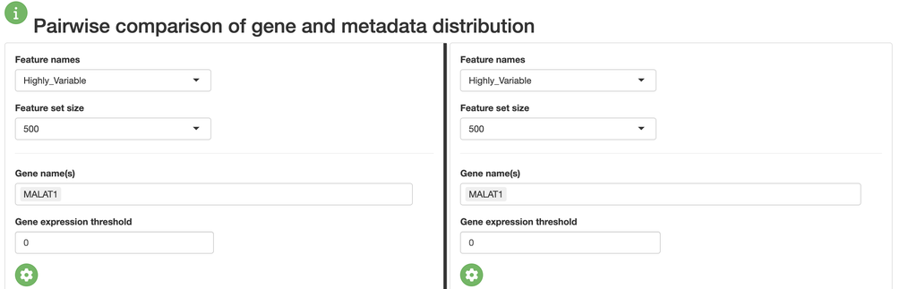

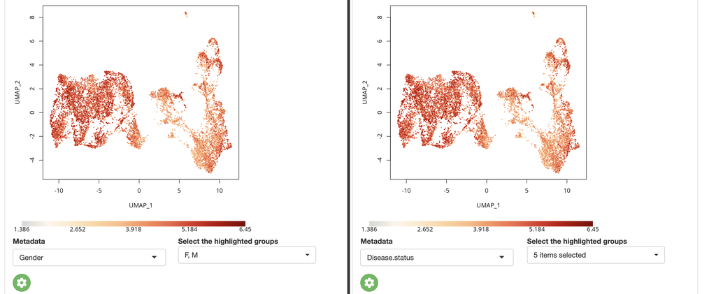

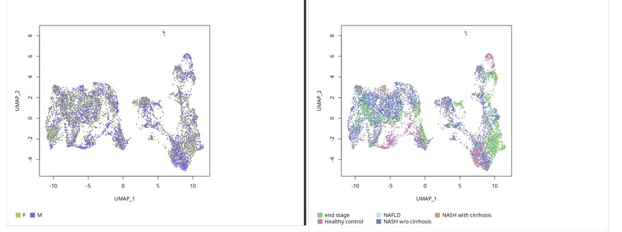

Figure 3.6: UMAP plots showing pairwise gene expression against metadata features

## 3.5 Choosing a feature set

In order to suggest the most stable partition, we firstly rank all partitions on descending ECS values. The top half are intersected between the top overall ECS and overall incremental ECS. Remaining configurations are ranked based on the incremental interquartile ranges, choosing the most compact distribution.

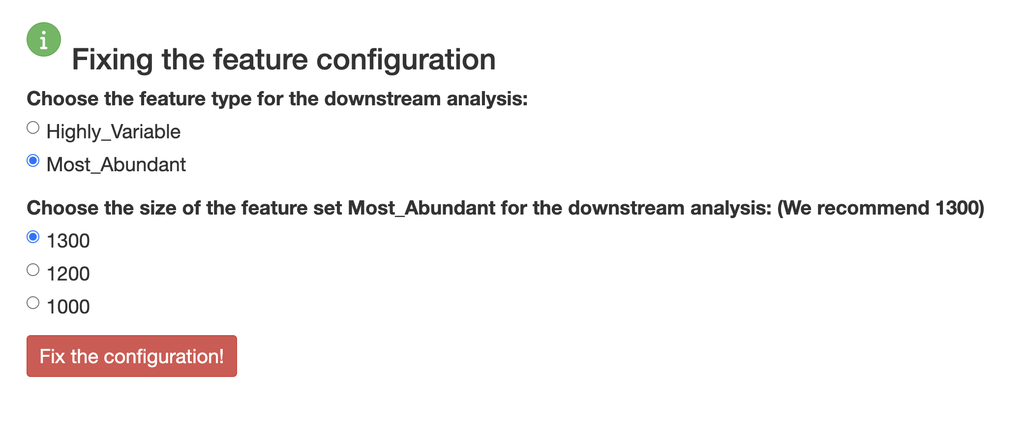

Figure 3.7: Feature set selection. You will not be allowed to carry on unless you have selected a feature set